www.nature.com/scientificreports

**Remyelination promoting therapies**

**in multiple sclerosis animal models:**

**a systematic review and meta-**

**analysis**

**Carlijn R. Hooijmans**<sup>**2**</sup>**, Martin Hlavica**<sup>**1**</sup>**, Florian A. F. schuler**<sup>**3,5**</sup>**, Nicolas Good**<sup>**1**</sup>**, Andrin Good**<sup>**1**</sup>**,**

**Lisa Baumgartner**<sup>**1**</sup>**, Gianluca Galeno**<sup>**1**</sup>**, Marc p. schneider**<sup>**1**</sup>**, tarzis Jung**<sup>**4**</sup>**, Rob de Vries**<sup>**2**</sup> **&**

**Benjamin V. Ineichen**<sup>**1,4**</sup>

**An unmet but urgent medical need is the development of myelin repair promoting therapies for Multiple**

**Sclerosis (MS). Many such therapies have been pre-clinically tested using different models of toxic**

**demyelination such as cuprizone, ethidium bromide, or lysolecithin and some of the therapies already**

**entered clinical trials. However, keeping track on all these possible new therapies and their efficacy**

**has become difficult with the increasing number of studies. In this study, we aimed at summarizing**

**the current evidence on such therapies through a systematic review and at providing an estimate of**

**the effects of tested interventions by a meta-analysis. We show that 88 different therapies have been**

**epithelium-derived factor, Plateled derived growth factor, and Tocopherol derivate TFA-12.We also**

**show that failure in bench to bedside translation from certain therapies may in part be attributable to**

**poor study quality. By addressing these problems, clinical translation might be smoother and possibly**

**animal numbers could be reduced.**

Multiple Sclerosis (MS) is a chronic demyelinating disease<sup>1</sup>. With the only exception of Ocrelizumab<sup>2</sup>, which

has a modest impact on disease progression, none of the 16 FDA approved MS therapies are able to stop or at

least to decelerate the progressively increasing disability of affected patients<sup>3</sup>. One well-acknowledged approach

to prevent disease progression is via a boost of myelin repair. Remyelination not only restores efficient electric

conduction along axons but, because the myelin sheaths have trophic functions for the axons<sup>4</sup>, also reduces neu-

rodegeneration, which closely correlates with clinical disability<sup>5</sup>.

The intense search for strategies to enhance myelin regeneration to hinder further neurodegeneration and

to increase clinical function of patients, is as well reflected by the large number of pre-clinical studies assessing

potential remyelinating strategies. Commonly used experimental systems to study potential remyelinating ther-

apies include neuro-inflammatory animal models such as experimental autoimmune encephalomyelitis (EAE)<sup>6</sup>

or virus-induced demyelination/inflammation<sup>7</sup> as well as toxin-induced demyelination models with cuprizone<sup>8</sup>,

lysolecithin, ethidium bromide, and complement/anti-galactocerebroside antibodies<sup>9</sup> being the most commonly

used agents of the latter group<sup>10</sup>. All of these models have strengths and limitations; whereas neuro-inflammatory

models reproduce well the disseminated and inflammatory features of MS, toxin-induced demyelination models

are more suited to dissect specific mechanisms of myelin decline and regeneration with a clear temporal separa-

tion of these processes and without concomitant inflammation<sup>10</sup><sup>,</sup><sup>11</sup>.

1Brain Research Institute, University of Zurich and Department of Health Sciences and Technology, ETH Zurich, 8057

Zurich, Switzerland. <sup>2</sup>Systematic Review centre for Laboratory Animal experimentation (SYRcLe), Department of

Health evidence, Radboud University Medical center, nijmegen, the netherlands. <sup>3</sup>institute of neuroinformatics,

University of Zurich and etH Zurich, Zurich, Switzerland. <sup>4</sup>Waidspital Zurich, Department of Radiology, tiechestrasse

99, 8037, Zurich, Switzerland. <sup>5</sup>Present address: Department of neurology, inselspital, Bern University Hospital,

University of Bern, Bern, Switzerland. carlijn R. Hooijmans and Martin Hlavica contributed equally. correspondence

and requests for materials should be addressed to B.V.i. (email: ineichen@protonmail.ch)

Received: 2 May 2018

Accepted: 30 October 2018

**opeN**

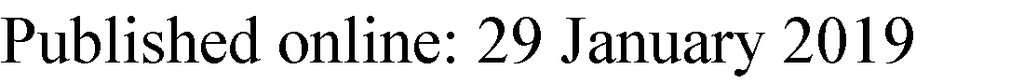

2

Cuprizone is a systemic copper-chelating agent. Upon feeding, it leads to demyelination of distinct brain

regions, among them the corpus callosum. Cuprizone has a highly reproducible timeline of de- and remyeli-

nation and enables long-term demyelination when fed for a prolonged time window. The exact mechanism of

cuprizone-induced demyelination is unknown<sup>10</sup><sup>,</sup><sup>12</sup>. Compared to Cuprizone, lysolecithin has the disadvantage

of needing an invasive injection to a pre-defined CNS-position. Nevertheless, it is also highly predictive under

temporal aspects. Moreover, any CNS area can be targeted selectively with this detergent<sup>13</sup>. Ethidium bromide

leads to much larger areas of demyelination and degrades all nucleated cells within the injection area (including

astrocytes and microglia cells)<sup>9</sup>. The local injection of Anti-galactocerebroside antibodies/complement is rarely

used as toxic demyelination model. The time to complete remyelination is shorter in this model but involves a

greater demyelinating area than lysolecithin<sup>10</sup>.

Many putative therapies have been identified using these toxic demyelination models, from which some

already entered clinical trials. We aimed at summarizing all the already pre-clinically tested putative remyelinat-

ing therapies via a systematic review and meta-analysis in order to assess which remyelinating therapies can be

promising and could be tested in clinical trials. We also investigate the efficacy of the therapies in these experi-

mental animal models that have already entered clinical trials. We focused our analysis on the four *in vivo* toxic

demyelination models cuprizone, lysolecithin, ethidium bromide, and complement/anti-galactocerebroside anti-

bodies. These models might be more suited to assess potential therapies aiming at halting disease progression of

progressive MS in contrast to neuro-inflammatory models, in which potential immune-modulatory effects of

therapies could confound efficacy<sup>11</sup>. The results of our review should provide a framework for future clinical trials

investigating putative remyelinating interventions for MS, in particular during the chronic phase of the disease

when remyelination failure determines disability progression.

**Results**

**study characteristics.**

*Study selection process*. Figure 1 depicts the Quorum flow chart of the study selec-

tion process<sup>14</sup>. Using 4 different search strings for anti-galactocerebroside antibodies, cuprizone, ethidium bro-

mide, and lysolecithin, respectively (see Supplementary Information), a total of 6545 publications were retrieved

from EMBASE, go3R, Medline, Pubmed, Scopus, and Web of Sciences. After initial screening of titles and

abstracts, 263 publications were included for full-text search. Out of these, 103 studies met our inclusion criteria

(see supplementary reference list). The remainder were excluded according to the criteria listed in Fig. 1.

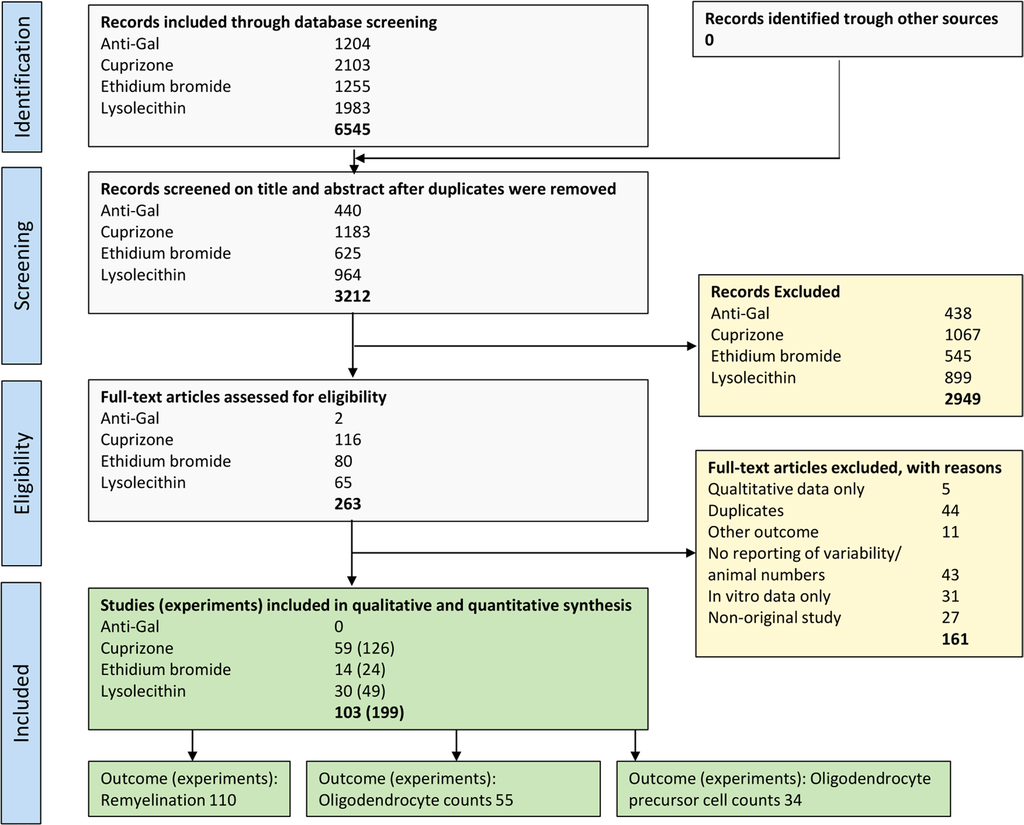

**Figure 1.** Quorum chart of the study selection process<sup>14</sup>. Duplicate references are references that are mentioned

in multiple medical databases (e.g. same references in Embase and Pubmed) or studies published in duplicate

(e.g. same study in multiple journals).

3

*Publication over time.* The first reports using models of toxic demyelination *in vivo* were published in the sev-

enties. Lysolecithin was the first model being published in 1971<sup>15</sup>, followed by cuprizone in 1972<sup>16</sup>, ethidium bro-

mide in early 1979<sup>17</sup>, and anti-galactocerebroside antibodies in mid 1979<sup>18</sup>. The first reports using these models

to assess a therapy for its remyelinating potential *in vivo* and meeting our inclusion criteria, however, was only in

1997<sup>19</sup>. Thus, all studies included in the meta-analysis were published between 1997 and 2016 (Fig. 2).

*Description of the included studies.* The characteristics of the 103 included studies are shown in Supplementary

Table 1. A total of 88 different therapies were tested in the included studies. 59 studies used cuprizone (58%), 30

studies used lysolecithin (29%), 14 studies used ethidium bromide (13%), and none of the included studies used

anti-galactocerebroside antibodies as demyelination model. Only two different animal species have been used in

the included studies: mice (72 studies, 70%) and rats (31 studies, 30%). Most studies used male animals (47, 45%),

whereas females were less commonly used (28, 27%); 25 studies (24%) did not report which sex they used, and

3 studies (3%) combined female and male animals within the same experimental groups. Most of the studies

used remyelination as an outcome measure (95, 93%), 54 of them (52%) investigated remyelination as the single

*Study quality and risk of bias.* Figure 4 depicts the risk of bias assessment for the 103 included studies. For many

items of the adapted SYRCLE risk of bias tool<sup>20</sup>, poor reporting regarding experimental details led overall to an

unclear risk of bias. Assessment of selection bias showed that none of the included studies described whether or

not they blinded the allocation of the animals to the experimental or groups or described the methods used for

allocation sequence generation. Although only 5% of the papers reported any measure used to randomise the

experiment, fortunately 68% of publications reported similar experimental groups at baseline. Regarding the risk

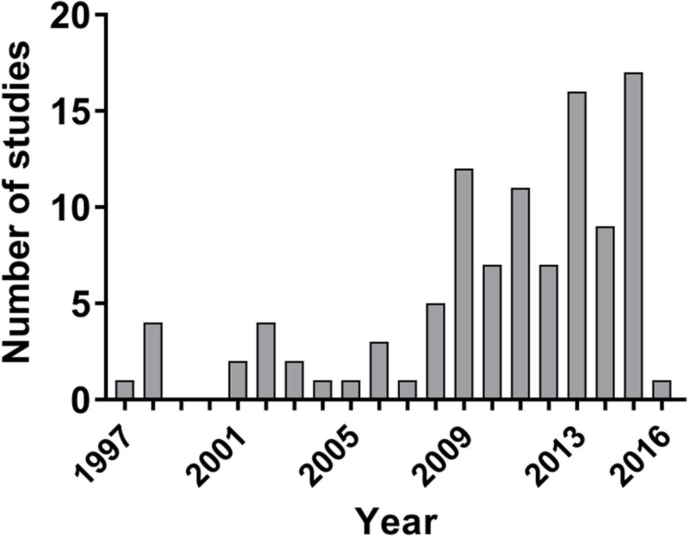

**Figure 2.** Histogram depicting the number of included studies per year.

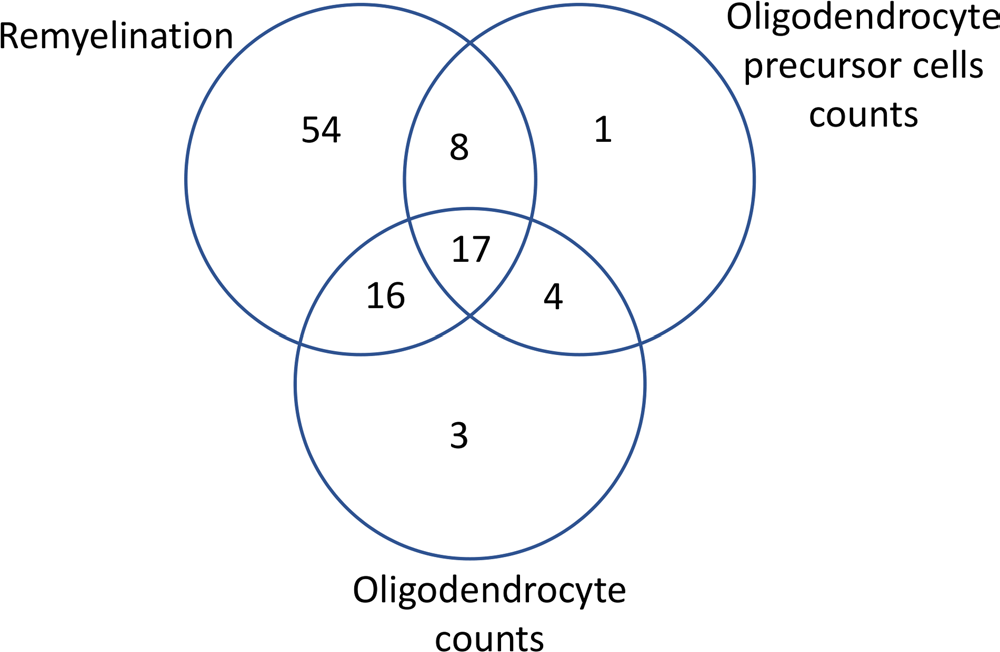

**Figure 3.** Venn diagram illustrating how many of the 103 studies assessed one or more of the outcomes

remyelination, oligodendrocyte precursor (OPC) count, and oligodendrocyte count.

4

of performance bias, none of the publications reported whether the animals were randomly housed across cages

and rooms during the experiment. 38% of the publications reported that staff was blinded during the experi-

ments. Concerning the risk of detection bias, none of the publications reported on random outcome assessment

whereas in 13% of the studies, the outcome assessor had been blinded for animal allocation. Measures to reduce

attrition bias were reported in 10% of publications. There was a high risk of attrition bias in 3%. In 87%, the risk of

attrition bias was unclear as a consequence of poor reporting of the number of experimental animals used in both

methods and result sections of the papers. Sample sizes appeared small in most of the included studies, although

only 2% of the included studies reported a a prior sample size calculation. The median number of animals in the

treatment or control group was between 5 and 5.5 (Table 1).

Because poor reporting in preclinical studies is a known problem and therefore many items of the risk of bias

tool are scored as unclear risk of bias, we additionally scored two reporting items. These items were also scored in

a similar study in EAE<sup>21</sup> and in focal cerebral ischemia (FCI)<sup>22</sup>: Five percent of studies reported randomization at

any level (For comparison - EAE: 9%, FCI: 36%). Blinding of the experiment at any level was reported in 38% of

studies (For comparison - EAE: 16%, FCI: 29%).

Finally, 2 studies (1.8%) reported a prior sample size calculation (EAE: <1%, FCI: 3%) whereas 2 studies

(1.8%) reported no prior sample size calculation. The remaining publications did not mention whether a sample

size calculation has been performed. Compliance with animal welfare regulations or an approved animal license

were reported in 58% of cases (For comparison - EAE: 32%, FCI: 57%). A statement whether a conflict of interest

was present was reported in 38% of studies (For comparison - EAE: 6%, FCI: 23%).

**Meta-analysis.**

*Remyelination as outcome*. In the studies measuring remyelination, different methods were

used in the 110 comparisons: most investigators used electron microscopy as outcome (32 experiments, 29%),

followed by myelin basic protein (MBP) immunohistofluorescence/-chemistry (26 experiments, 24%), Luxol Fast

Blue (LFB) staining (17 experiments, 15%), and Toluidine blue staining on semithin sections (11 experiments,

10%). In contrast, Black Gold staining (8 experiments, 7%), Hematoxylin and Eosin staining (5 experiments, 5%),

PLP immunohistofluorescence (4 experiments, 4%), Eriochrome staining (3 experiments, 3%), MOG immuno-

histochemistry (2 experiments, 2%), MRI lesion load (1 experiment, 1%), and MRI magnetization transfer (1

experiment, 1%) were less commonly used.

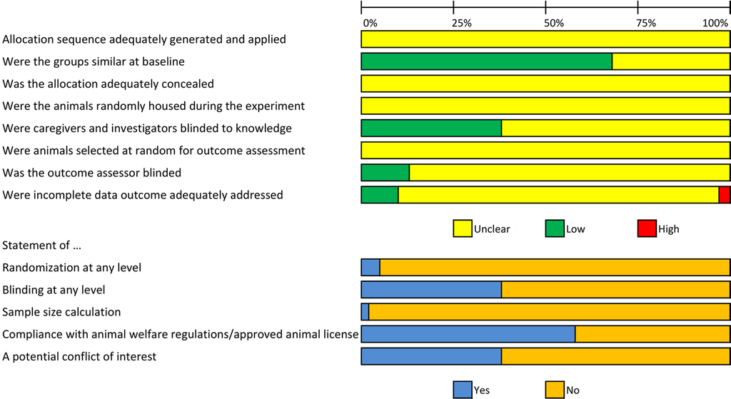

**Figure 4.** Risk of bias assessment of the included studies. The first 8 items assess study quality by reporting

“yes” indicating low risk of bias, “no” high risk of bias, and “unclear” as not reported<sup>20</sup>. The remaining 5 items

score a “yes” if reported and a “no” if not reported.

**Outcome**

**Median/mean number**

**(****±****SD) of animals in**

**treatment group**

**Median/mean number**

**(****±****SD) of animals in**

**control group**

**Range**

Remyelination

5.5/6.7 (±3.7)

5/6.1 (±3.7)

2–21

Oligodendrocyte

cell counts

5/6.5 (±3.7)

5/6.1 (±3.5)

3–18

OPC counts

5/6.5 (±3.8)

5/6.4 (±3.7)

3–21

**Table 1.** Sample sizes of the included studies, Abbreviations: SD, standard deviation; OPC, oligodendrocyte

precursor cells.

5

Pooling the individual effect sizes of all therapies in our meta analyses showed that the therapies described in

literature enhance remyelination (Standardized mean difference (SMD): 1.61, 95% CI: [1.26, 1.97], Table 2). The

overall heterogeneity<sup>23</sup> between the studies, however, was high (I2 = 85%), reflecting the anticipated differences

between interventions, models used and study design.

In order to obtain a more detailed overview of the efficacy of the various therapies included in this review,

we also analysed the effect of the seventy-eight different therapeutic approaches in 110 different comparisons for

their remyelination potential as measured by different morphometric approaches (i.e. the quantification of thinly

myelinated axons in electron microscopy or by similar methods) separately. Nineteen therapeutic approaches

significantly enhanced remyelination (Anti-Lingo-1-antibody, Ebselen, Electro acupuncture, Electromagnetic

field stimulation, Epimedium flavonoids, Glatiramer acetate, Indazol chloride, N6-cyclohexyladenosine,

Neurotrophin 3, Ninjińyoeito, Plateled-derived growth factor, Progesterone, Quetiapine, Sildenafil, SiRNA

against Nogo-receptor, Testosterone, Tocopherol derivate TFA12, Triiodothyronine, and Vitamin E) and four

therapies dampened the remyelination after experimental demyelination (Dizocilipine, Simvastatin, Trapidil, and

Valproic acid) (Figs 5 and 6). For the remaining 55 therapeutic approaches, no statistically significant results were

found. In many cases, only one or a few studies were available per therapeutic approach.

Further subgroup analyses for timing of the intervention (e.g. prophylactical or therapeutical administration)

or type of model used revealed no differences. Due to the small number of comparisons in the subgroups, these

results must be interpreted with caution.

*Oligodendrocyte precursor cell (OPC) count as outcome.* In the studies visualizing OPCs, different methods were

used in the 34 different comparisons: NG2 was the most commonly used marker for OPCs (19 experiments,

56%), followed by PDGFRα (13 experiments, 38%). In contrast, Nkx2.2 (2 experiments, 6%) was less commonly

used.

Pooling the individual effect sizes (SMDs) of all 34 experiments investigating the effect of various therapies on

OPC counts did not show a significant effect (SMD: 0.87, 95% CI: [−0.08, 1.83], Table 3). The overall heteroge-

neity was very high (I2 = 92%).

Thirty-one different therapeutic approaches in 34 different comparisons were tested for their impact on

OPC counts as measured by cell counts of different immune-staining methods (i.e. NG2, PDGFRα, or Nkx2.2).

The effectsizes (SMDs) and 95% CIs indicated that 7 therapeutic approaches significantly increased the OPC

count (Electro acupuncture, Iloprost, Pigment epithelium-derived factor (PEDF), Platelet-derived growth factor

(PDGF), Testosterone, Triiodothyronine, and Valproic acid) and 3 therapies significantly decreased the OPC

count after experimental demyelination (Apotransferrin, Epimedium flavonoids, and Lactacystin) (Fig. 7). For

the remaining 21 therapeutic approaches, no statistically significant effects were found. In many cases, only one or

a few studies were available per therapeutic approach. No statistically significant differences between subgroups

could be identified for type of model used or timing of the intervention (the subgroup of prophylactic adminis-

tration was too small).

*Oligodendrocytes as outcome.* In the studies visualizing oligodendrocytes, different methods were used in the

55 comparisons: APC (CC1) was the most commonly used marker for oligodendrocytes (20 experiments, 36%),

followed by GST-pi (11 experiments, 20%), and Nogo-A (9 experiments, 16%). In contrast, CA2 (5 experiments,

9%), CNP (4 experiments, 7%), O4 (3 experiments, 5%), and Olig2/APC (CC1) double staining (3 experiments,

5%), were used less commonly.

**Subgroup**

**Comparisons**

**Effect estimate**

**[95% CI]**

**I**<sup>**2**</sup>

**Overall**

**110**

**1.61** [**1.26, 1.97]**

**85%**

**MS model**

Cuprizone

66

1.61 [1.16, 2.07]

83%

Ethidium bromide

16

1.67 [0.68, 2.65]

87%

Lysolecithin

28

1.60 [0.90, 2.30]

86%

**Method**

Electron microscopy

32

1.73 [1.05, 2.40]

87%

MBP immuno-staining

26

2.16 [1.44, 2.87]

82%

Luxol fast blue

17

1.85 [0.97, 2.73]

79%

H&E lesion area

5

5.17 [2.83, 7.51]

92%

MOG immune-staining

2

3.29 [0.23, 6.35]

85%

**Therapeutic regimen**

therapeutically

102

1.67 [1.30, 2.04]

84%

**Table 2.** subgroup analysis of the included studies for outcome remyelination. The effect estimate was displayed

by the standardized mean difference (SMD) and 95% confidence intervals (CIs). No significant differences

were found in the subgroup analyses. Abbreviations: MBP, myelin basic protein; MOG, myelin oligodendrocyte

glycoprotein.

6

Meta analyses showed that the assessed therapies can increase oligodendrocyte cell counts (SMD: 2.09, 95%

CI: [1. 52, 2.66], Table 4). The overall heterogeneity, however, was high (I2 = 87%), reflecting the anticipated dif-

ferences between interventions, models used and study design.

Subsequently, we investigated the effect of each therapy separately on oligodendrocytes cell counts. Forty-three

different therapies in 55 different comparisons were tested for their impact on oligodendrocyte cell counts as

measured by cell counts of different immune-staining methods (e.g. APC, CA2, Nogo-A, or others). The SMDs

and 95% CIs indicated that 12 therapies significantly increased the oligodendrocyte cell counts (Apotransferrin,

Benztropine, Electro acupuncture, Estrogen receptor agonist G1, Olesoxime, Pigment epithelium derived factor,

Progesterone, Quetiapine, Sonic hedgehog, Testosterone, Tocopherol derivate TFA-12, and Triiodothyronine)

and one therapy significantly decreased the oligodendrocyte cell counts after experimental demyelination (val-

proic acid, SMD −11.77, 95%-CI [−18.04, −5.49], 1 comparison) (Fig. 8). For the remaining 30 therapeutic

approaches, no statistically significant results were found.

The number of independent comparisons per therapeutic approach were very low and varied between 1 and

4. No differences between subgroups were found for timing of the intervention. However, subgroup analyses for

type of model used revealed that the type of model used to measure oligodendrocytes cell counts partly explains

the observed heterogeneity between the studies. use of the LPC model significantly yielded more oligodendrocyte

cell counts compared to the cuprizone model (p < 0.001).

**publication bias.**

Both visual inspection of the funnel plot and Egger regression did not suggest the presence

of publication bias for remyelination, OPCs, and oligodendrocyte data. The funnel plots show no significant

asymmetry, and no trimming could be performed (Fig. 9). Egger regression also showed no evidence for small

study effects (remyelination p = 0.153, OPCs p = 0.063, oligodendrocytes p = 0.99).

**synopsis of the results.**

Table 5 compares the therapies with a significant result in the meta-analysis and

their impact on the outcomes remyelination, OPC count, and oligodendrocyte count and indicates whether a

therapy has already entered a clinical trial. Most of the therapies that entered a clinical trial showed a beneficial

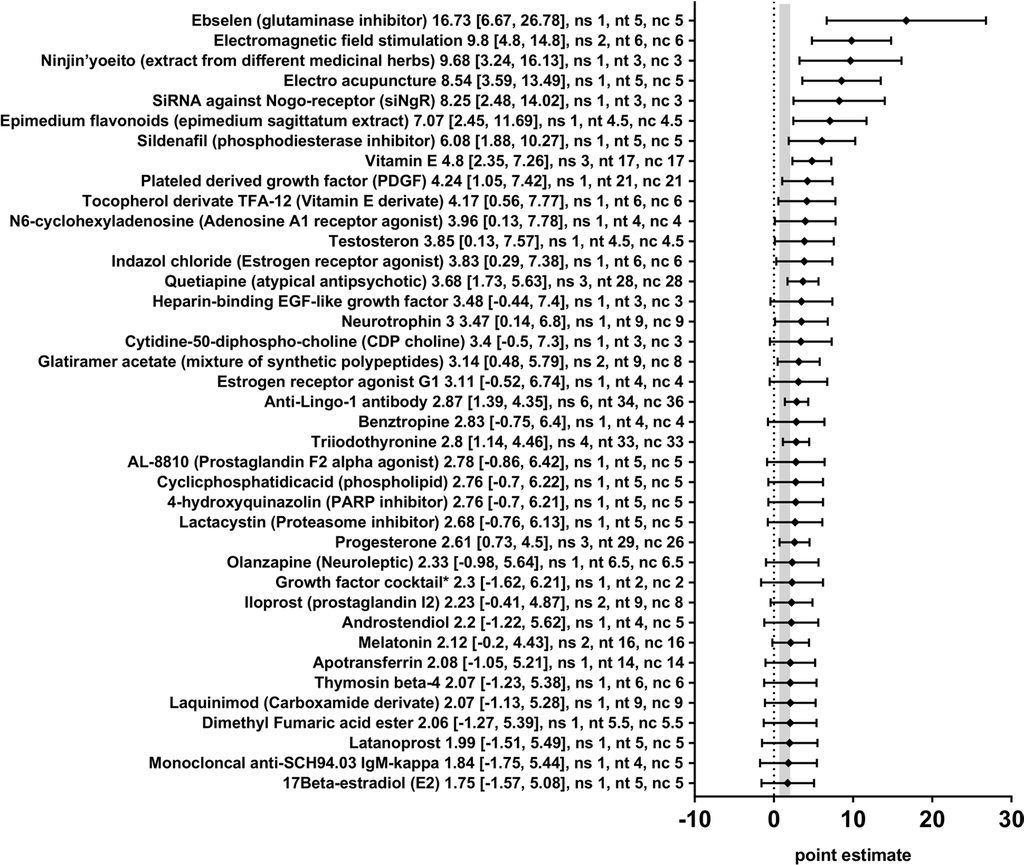

**Figure 5.** Forest plot of the included studies for the outcome remyelination (part 1). The diamond indicates

the global estimate and its 95% confidence interval (CI). The numbers listed after a certain intervention are: the

exact effect size with its 95% CI, the number of included studies for a certain intervention (ns), the total number

of treated animals (nt) or control animals (nc). The gray bar indicates the 95% CI of the overall effect size.

References are given in the Supplementary Information. *The growth factor cocktail contained Platelet derived

growth factor-AA, neurotrophin-3, basic fibroblast growth factor, and insulin-like growth factor-1.

7

effect in at least one of the three outcomes, except for Simvastatin (2 comparisons for remyelination, 1 for each

OPC and oligodendrocyte counts). Simvastatin significantly decreased remyelination in experimental animal

models and showed no effect on either OPC and oligodendrocyte numbers, but is already being tested in a phase

A1 receptor agonist), Neurotrophin 3, Ninjin’yoeito (an extract from different medicinal herbs), Olesoxime (a

cholesterol-like compound), Pigment epithelium-derived factor (PEDF), Plateled derived growth factor (PDGF),

Sildenafil (a phosphodiesterase inhibitor), siRNA against Nogo-receptor, Sonic hedgehog, and Tocopherol deri-

vate TFA-12 (a Vitamin E derivate). For most therapies, however, only one comparison was available for our

meta-analysis. Three of these possible therapies seem very promising as they scored a significant increase in 2 of

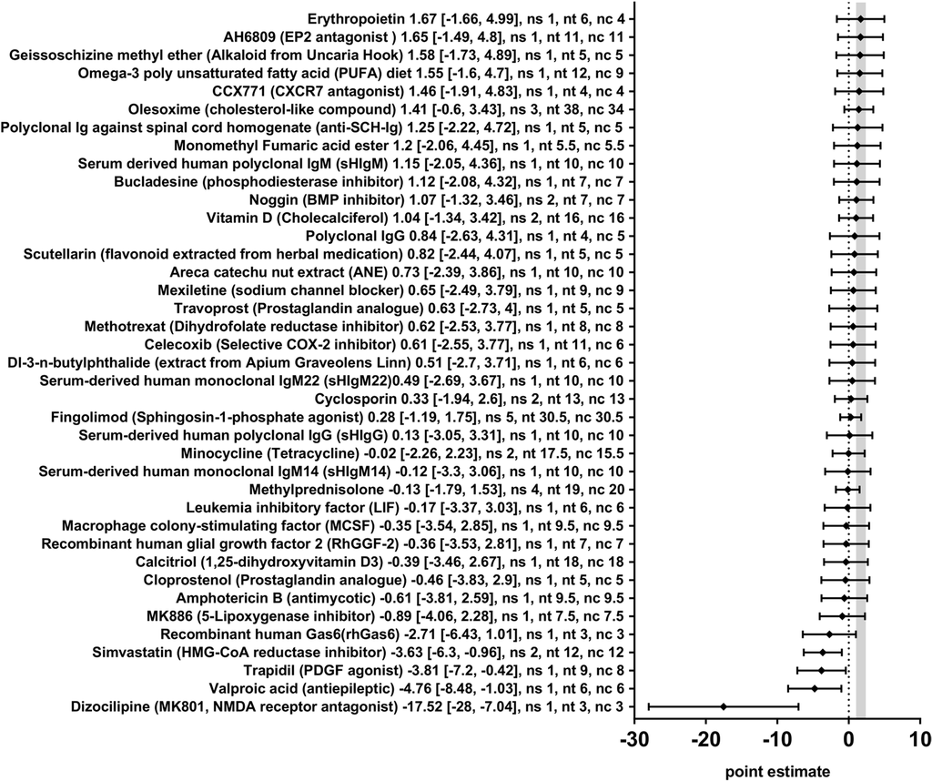

**Figure 6.** Forest plot of the included studies for the outcome remyelination (part 2). The diamond indicates

the global estimate and its 95% confidence interval (CI). The numbers listed after a certain intervention are: the

exact effect size with its 95% CI, the number of included studies for a certain intervention (ns), the total number

of treated animals (nt) or control animals (nc). The gray bar indicates the 95% CI of the overall effect size.

References are given in the Supplementary Information.

**Subgroup**

**Comparisons**

**Effect estimate [95% CI]**

**I**<sup>**2**</sup>

**Overall**

**34**

**0.87** [**−****0.08, 1.83]**

**92%**

**Therapeutic regimen**

therapeutically

29

1.31 [0.25, 2.37]

93%

**Method**

PDGFRα

13

2.50 [0.51, 4.49]

94%

**Table 3.** subgroup analysis of the included studies for outcome oligodendrocyte precursor cell counts. The

effect estimate was displayed by the standardized mean difference (SMD) and 95% confidence intervals (CIs).

No significant differences were found in the subgroup analyses.

8

the 3 outcome measures assessed and no negative effects in the remaining outcome: PDGF, PEDF, and Tocopherol

derivate TFA-12 (each with one comparison). In Fig. 10, the meta-analysis outcomes remyelination, oligoden-

drocyte cell/OPC cell counts are plotted against each other for each therapy, which has been tested in at least two

outcomes. The scatter plots demonstrate a good correlation (Pearson’s r = 0.51, two-tailed p = 0.02) between the

outcome remyelination and oligodendrocytes.

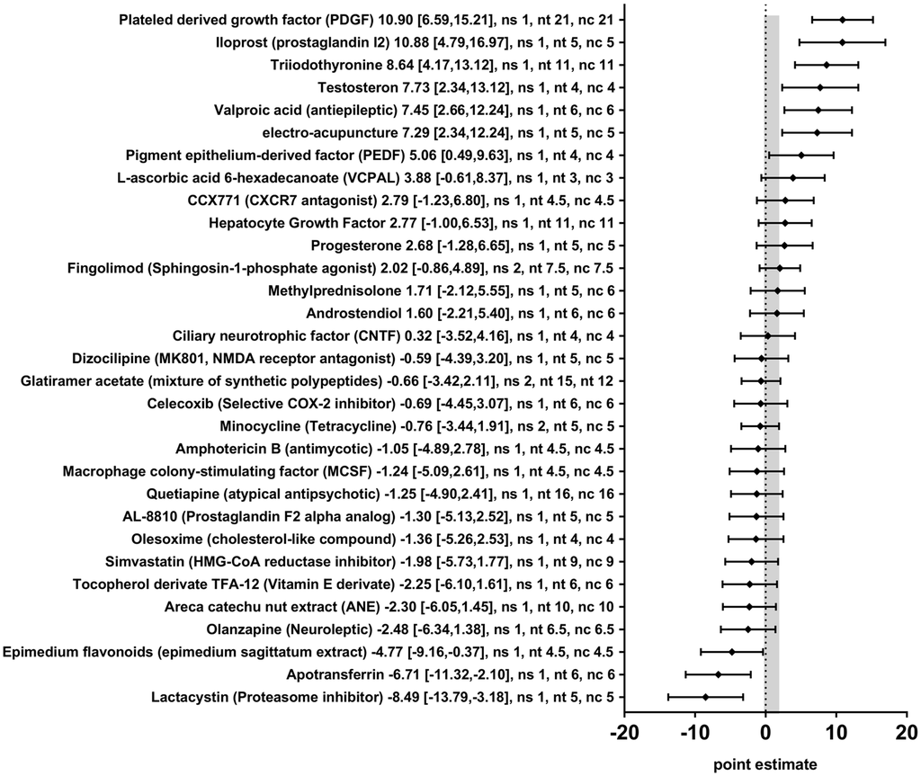

**Figure 7.** Forest plot of the included studies for outcome oligodendrocyte precursor cell (OPC) count. The

diamond indicates the global estimate and its 95% confidence interval (CI). The gray bar indicates the 95% CI

of the overall effect size. The numbers listed after a certain intervention are: the exact effect size with its 95%

CI, the number of included studies for a certain intervention (ns), the total number of treated animals (nt) or

control animals (nc). References are given in the Supplementary Information.

**Subgroup**

**Comparisons**

**Effect estimate [95% CI]**

**I**<sup>**2**</sup>

**Overall**

**55**

**2.09** [**1.52, 2.66]**

**87%**

**Therapeutic regimen**

therapeutically

49

2.10 [1.48, 2.71]

86%

**Method**

APC*

20

2.43 [1.48, 3.38]

88%

GST-pi

11

2.14 [0.91, 3.37]

83%

Nogo-A*

9

0.12 [−1.16, 1.36]

72%

CA2

5

3.64 [1.71, 5. 57]

83%

O4

3

4.86 [2.31, 7.41]

96%

Olig2/APC

3

2.51 [0.13, 4.89]

48%

**MS model**

Cuprizone***

42

1.77 [1.12, 2.41]

86%

Lysolecithin***

10

3.71 [2.27, 5.15]

91%

**Table 4.** Subgroup analysis of the included studies for outcome oligodendrocytes cell counts. The effect

estimate was displayed by the standardized mean difference (SMD) and 95% confidence intervals (CIs).

*Significant subgroup analysis between Nogo-A and APC (adjusted p = 0.049), and Cuprizone and Lysolecithin.

9

**Clinical trials.**

Table 6 summarizes the therapies that were tested in toxic demyelination models that have

entered clinical trials (phase 1 to 4). Out of 88 interventions identified by our systematic review, 25 (28%) have

already entered clinical trials. Five of these reached FDA-approval (Fingolimod, Fumaric acid ester, Glatiramer

acetate, Methotrexate, Methylprednisolone).

**Discussion**

Finding remyelinating therapies for MS is an urgent and unmet medical need because no such therapies are cur-

rently available. Regeneration of myelin sheaths would re-enable efficient electrical conduction along axons and

furthermore protect axons from neurodegeneration<sup>4</sup>. Many such potential approaches have been pre-clinically

tested so far. In order to obtain an overview of possible promising remyelinating therapies, we systematically

reviewed pre-clinical studies assessing therapies aiming at improving myelin repair. Our review provides evidence

that pre-clinically tested therapies significantly increase remyelination and oligodendrocyte cell counts overall. In

addition, we show that there are numerous other therapies that seem promising based on our meta-analysis that

are not yet tested in clinical trials.

Overall meta-analysis of the outcome remyelination showed that 19 out of 78 therapies (24%) enhanced remy-

elination. Four therapies dampened the remyelination, among them valproic acid and Simvastatin (1 and 2 com-

parisons included, respectively). Nevertheless, Simvastatin was, based on experimental studies conducted in EAE,

already tested in several clinical trials due to its presumptive immunomodulatory and neuroprotective effects<sup>24</sup>. It

appeared to be successful in a recent phase 2 trial in secondary progressive MS patients<sup>25</sup><sup>,</sup><sup>26</sup>. It failed, however, in

nomodulation might be its primary mode of action<sup>24</sup>. Besides that, Simvastatin, a blood-brain barrier permeable

statin, is an inhibitor of cholesterol synthesis. It has been shown *in vitro* and *in vivo* to dampen the maturation/

differentiation of OPCs to myelinating oligodendrocytes via inhibition of the Rho kinase (ROCK) downstream

pathway<sup>28</sup><sup>,</sup><sup>29</sup>. Another statin, Lovastatin has also been shown to affect OPC maturation *in vitro*, namely by inhi-

bition of the cholesterol synthesis thereby affecting the proteolipid protein (PLP) transport towards the myelin

sheaths<sup>30</sup>. It seems therefore plausible that one should carefully monitor the effect of statins in the therapy of MS

and other demyelinating diseases<sup>29</sup><sup>,</sup><sup>30</sup>.

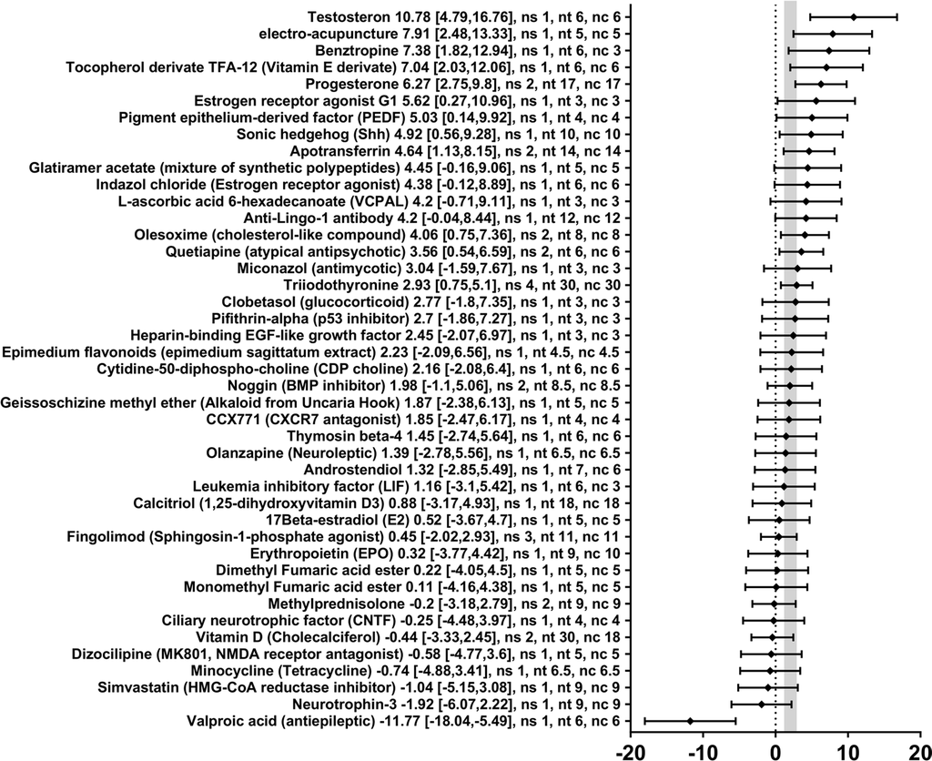

**Figure 8.** Forest plot of the included studies for outcome oligodendrocyte count. The diamond indicates the

global estimate and its 95% confidence interval (CI). The gray bar indicates the 95% CI of the overall effect

size. The numbers listed after a certain intervention are: the exact effect size with its 95% CI, the number of

included studies for a certain intervention (ns), the total number of treated animals (nt) or control animals (nc).

References are given in the Supplementary Information.

10

Meta-analysis of the outcome oligodendrocyte cell counts demonstrated that 12 out of 43 (28%) therapies

increased oligodendrocyte cell counts. Valproic acid was the only intervention significantly decreasing the oli-

godendrocyte cell count. Together with its increase in the OPC count, oligodendrocyte differentiation blocking

properties have been revealed (via inhibition of histone deacetylases)<sup>31</sup>. Intriguingly, this antiepileptic drug has

repeatedly shown beneficial effects in EAE and optic neuritis animal models<sup>32</sup><sup>,</sup><sup>33</sup>. Data from a retrospective cohort

study in MS patients were negative, however<sup>34</sup>. This emphasizes that a good pre-clinical scientific fundament for

a presumptive remyelinating therapy using also toxic demyelination models can help to decide whether a therapy

should be tested in a clinical trial.

Meta-analysis of the outcome OPC count revealed that 7 out of 31 therapies (23%) increased the OPC count

whereas 3 decreased it (Apotransferrin, Epimedium flavonoids, Lactacystin). Overall analysis of the outcome

OPC count revealed no statistically significant effect. Assessing OPC count as the single outcome for a presump-

tive remyelinating therapy is not ideal because increased OPC counts can be at the cost of decreased oligoden-

drocyte counts (cell differentiation block), as shown by the absence of correlation between OPC counts and

remyelination in our analysis. This fits also to the extensive evidence showing that OPCs can be present at the

border or even inside experimental demyelinated lesions<sup>35</sup><sup>,</sup><sup>36</sup> and chronic demyelinated MS lesions<sup>37</sup><sup>–</sup><sup>42</sup> without

differentiating to oligodendrocytes. Proof of this OPC differentiation block with resulting remyelination failure

has led to a paradigm shift in the remyelination field, focusing more on ways to foster OPC differentiation than

OPC proliferation<sup>43</sup><sup>,</sup><sup>44</sup> (reviewed in<sup>45</sup>).

Interestingly, the meta-analysis outcomes remyelination and oligodendrocyte cell counts showed a significant

positive correlation when plotted against each other. This possibly shows that remyelination alone might be a

sufficient outcome measure for future pre-clinical trials.

**Clinical relevance and recommendations.**

strategies that have not yet been tested in clinical trials but seem promising (i.e. Apotransferrin, Benztropine,

Epimedium flavonoids (extract of epimedium sagittatum), Estrogen receptor agonist G1, Iloprost (prostaglandin

I2), Indazol chloride (an Estrogen receptor agonist), N6-cyclohexyladenosine (Adenosine A1 receptor agonist),

Pigment epithelium-derived factor (PEDF), Plateled derived growth factor (PDGF), Sildenafil (phosphodiester-

ase inhibitor), siRNA against Nogo-receptor, Sonic hedgehog, and Tocopherol derivate TFA-12 (Vitamin E deri-

vate)). Our results suggest that treatment with PDGF, PEDF, or Tocopherol derivate TFA-12 are particularly

interesting for further investigations because treatment with these drugs showed favourable outcomes in two out

of three of our remyelinating outcomes.

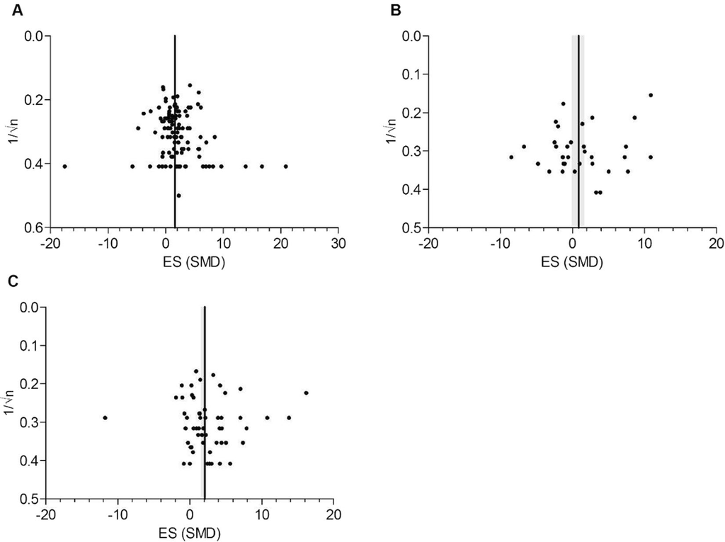

**Figure 9.** Evaluation of publication bias. Panel A, B and C represent the funnel plots for the outcomes

remyelination, oligodendrocyte precursor cells (OPC) and oligodendrocyte count. The line represents the SMD

of the summary effect, the grey bands represent global 95% confidence intervals.

www.nature.com/scientificreports/

11

Following this, it would also be very useful to investigate whether the results of the currently conducted clini-

cal trials show comparable results with our review results.

**Correlation with therapies which have entered clinical trials.**

For some of the clinical trials the

results are already published. Whereas some pre-clinically assessed therapies therapies already reached mar-

ket approval, the clinical translation is sometimes hampered. A good example are anti-Lingo-1 antibodies.

These antibodies effectively and consistently enhanced remyelination in different MS animal models. However,

the failure of anti-Lingo-1-antibodies in a phase 2 trial to meet the primary outcome in relapsing/progressive

MS patients, a multicomponent analysis evaluating motor and cognitive function as well as disability, were

sobering (http://media.biogen.com/press-release/investor-relations/biogen-reports-top-line-results-phase-

2-study-opicinumab-anti-lingo). In our meta-analysis, anti-Lingo-1-antibodies did only show a significant

increase in remyelination but not in oligodendrocyte cell counts. Cyclosporin is another therapy that showed ben-

eficial effects in the ethidium bromide model<sup>46</sup> (although not in our meta-analysis) but failed in clinical trials<sup>47</sup>.

Of course, some of these therapies made it into clinical trials not because of their results in toxic demyelination

models assessed here, but because of their results in neuro-inflammatory animal models such as EAE<sup>48</sup>.

**Limitations.**

An important limitation of this review, as in many other systematic reviews of animal stud-

ies<sup>49</sup> is that many of the essential methodological details of animal studies included in our review were poorly

reported. This seriously hampers reliable risk of bias assessment because in order to assess whether or not results

can be influenced by systematic errors and deviates from the truth, all important details regarding a specific type

of bias need to be reported. As a consequence, we can not reliably estimate how valid the results of the included

studies are. We nevertheless included the poorly reported papers in this review because papers that do not report

essential details are not necessarily methodologically impaired<sup>50</sup>. Nevertheless, it is important to emphasize

**Therapy**

**remyelination**

**OPCs**

**Oligodendrocytes**

**Tested in**

**clinical trial**

Anti-Lingo-1-antibodies

Increase (6)

Not tested

Not significant (1)

Yes (II)

Apotransferrin

Not significant (1)

Decrease (1)

Increase (2)

No

Benztropine

Not significant (1)

Not tested

Increase (1)

No

Dizocilipine (MK801, MNDA receptor antagonist)

Decrease (1)

Not significant (1)

Not significant (1)

No

Ebselen (glutaminase inhibitor)

Increase (1)

Not tested

Not tested

Yes (II)

Electro acupuncture

Increase (1)

Increase (1)

Increase (1)

Yes (II)

Electromagnetic field stimulation

Increase (2)

Not tested

Not tested

Yes (II)

Epimedium flavonoids (extract of epimedium sagittatum)

Increase (1)

Decrease (1)

Not significant (1)

No

Estrogen receptor agonist G1

Not significant (1)

Not tested

Increase (1)

No

Glatiramer Acetate (mixture of synthetic polypeptides)

Increase (2)

Not significant (2)

Not significant (1)

Yes (IV)

Iloprost (prostaglandin I2)

Not significant (2)

Increase (1)

Not tested

No

Indazol chloride (Estrogen receptor agonist)

Increase (1)

Not tested

Not significant (1)

No

Lactacystin (Proteasome inhibitor)

Not significant (1)

Decrease (1)

Not tested

No

N6-cyclohexyladenosine (Adenosine A1-receptor agonist)

Increase (1)

Not tested

Not tested

No

Neurotrophin 3

Increase (1)

Not tested

Not significant (1)

No

Ninjin’yoeito (extract from different medicinal herbs)

Increase (1)

Not tested

Not tested

No

Olesoxime (cholesterol-like compound)

Not significant (3)

Not significant (1)

Increase (2)

Yes (I)

Pigment epithelium-derived factor (PEDF)

Not tested

Increase (1)

Increase (1)

No

Plateled derived growth factor (PDGF)

Increase (1)

Increase (1)

Not tested

No

Progesterone

Increase (3)

Not significant (1)

Increase (2)

Yes (III)

Quetiapine (atypical antipsychotic)

Increase (3)

Not significant (1)

Increase (2)

Yes (II)

Sildenafil (phosphodiesterase inhibitor)

Increase (1)

Not tested

Not tested

No

Simvastatin (HMG-CoA reductase inhibitor)

Decrease (2)

Not significant (1)

Not significant (1)

Yes (IV)

siRNA against Nogo-receptor

Increase (1)

Not tested

Not tested

No

Sonic hedgehog

Not tested

Not tested

Increase (1)

No

Testosterone

Increase (1)

Increase (1)

Increase (1)

Yes (II)

Tocopherol derivate TFA-12 (Vitamin E derivate)

Increase (1)

Not significant (1)

Increase (1)

No

Trapidil (PDGF agonist)

Decrease (1)

Not tested

Not tested

No

Triiodothyronine

Increase (4)

Increase (1)

Increase (4)

Yes (I)

Valproic acid (antiepileptic)

Decrease (1)

Increase (1)

Decrease (1)

No

Vitamin E

Increase (3)

Not tested

Not tested

Yes (II)

**Table 5.** Summary of meta-analysis results for beneficial/harmful therapies on the outcomes remyelination,

oligodendrocyte precursor cell (OPC) count, and oligodendrocyte count. The numers in brackets in the second

to fourth columns indicate the number of comparisons for each outcome. The roman number in brackets in the

last column indicates the latest phase of clinical trial the therapy has entered.

www.nature.com/scientificreports/

12

that consistent reporting of essential details regarding experimental design for future animal experiments, as

described for example in the ARRIVE guidelines<sup>51</sup>, is urgently needed.

Secondly, in this review we focused on models of toxic demyelination, namely anti-galactocerebroside anti-

bodies, cuprizone, ethidium bromide, and lysolecithin. These models are believed to be more suited to assess

potential remyelinating interventions due to a clear temporal separation of de- and remyelination and only min-

imal overlying inflammatory processes<sup>11</sup>. This is in contrast to viral MS animal models or EAE, the most widely

used MS animal model, being yet more suitable to study (neuro-)inflammatory processes of MS<sup>52</sup>. A recent

meta-analysis revealed that Cyclosporin, Fingolimod, Glatiramer Acetate, Minocycline, and Vitamin D among

others improved neuro-behavioral outcome in EAE<sup>21</sup>. Glatiramer Acetate also had a beneficial effect on remyeli-

nation in our meta-analysis. Fingolimod, on the other hand, did not significantly enhance remyelination in our

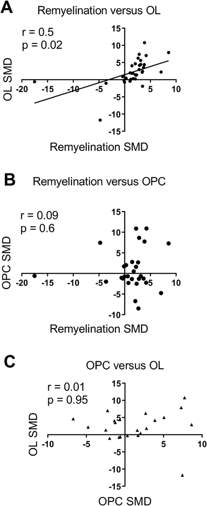

**Figure 10.** Scatter plot of standardized mean differences (SMD) from the present meta-analysis of therapies

which were assessed in at least two outcomes (remyelination, oligodendrocyte cell count (OL), oligodendrocyte

precursor cell count (OPC)). Remyelination versus OL (**A**) shows a significant positive correlation (Pearson’s

www.nature.com/scientificreports/

13

analysis. Both drugs are FDA-approved for relapsing MS. Interestingly, Methylprednisolone showed neither a

beneficial effect on neurobehavioral recovery nor on remyelination in the meta-analysis even though being com-

monly used as treatment for acute MS relapses. This emphasizes that despite the usefulness of MS animal models

in developing novel MS therapies, findings cannot be strictly translated to MS.

Thirdly, for many analyses the number of studies was low and the variation between the studies high. This

influences the reliability of the conclusions drawn from this systematic review. For example, in this review we

pooled the different toxic demyelination models as well as the different methods to assess the outcomes, neglect-

ing strengths and weaknesses of various models and outcomes individually. For example, the gold standard of

assessing remyelination is the evidence of thinly myelinated axons in electron microscopy. Thus, the most com-

monly used readout in the included studies to assess remyelination was the evidence of thinly myelinated axons

in electron microscopy (29%). Whereas methods demonstrating thinly myelinated axons are an acceptable com-

promise to show remyelination (e.g. semithin sections, MBP<sup>53</sup>, or sudan black<sup>54</sup>), other methods are less sensitive

does not reliably demonstrate single axon/myelin sheath resolution. For now, we have accounted for anticipated

heterogeneity by using a random rather than fixed effects meta-analysis.

Furthermore, it is important to realize that no animal model is a perfect match to represent the full clinical

situation. The results coming from animal studies are therefore always indirect<sup>55</sup><sup>,</sup><sup>56</sup>.

When the results of this review will be used to inform the clinical field, the applicability and feasibility of the

promising therapeutic strategies mentioned in this paper need to be carefully assessed as well. In addition, poten-

tial adverse side effects of therapies in both animals and humans is another important determinant for clinical

translation. Safety profile is completely neglected by our analysis (as it is in most pre-clinical studies, however) but

needs to be included for clinical translation.

**Phase**

**Count**

**Trial information**

**NCT (if available)**

1

4

Olesoxime

Add-on therapy for Interferon β1

NCT01808885

Serum-derived human

monoclonal IgM22

—

NCT01803867

Thymosin beta4

—

planned according to RegeneRX

Triiodothyronine

For RRMS, SPMS, and PPMS

NCT02506751, NCT02760056

**2**

10

Anti-Lingo-1 antibody

Add-on therapy for Interferon β1

NCT01864148

Cyclosporin<sup>61</sup>

Electro-acupuncture<sup>62</sup>

Electromagnetic field

stimulation<sup>63</sup>

Erythropoietin

PPMS or SPMS

NCT01144117

Melatonin

RRMS

NCT01279876

Quetiapine

For RRMS and SPMS

NCT02087631

Testosteron

For male patients

NCT00405353

Vitamin E

Combined with Selenium

NCT00010842

Ebselen

Combined with Vitamin E

NCT00010842

**3**

3

Laquinimod

For RRMS

NCT01047319

Minocycline

For clinically isolated syndrome

NCT00666887

Progesterone

To prevent postpartum relapses

NCT00127075

**4**

8

Fingolimod

FDA-approved for RRMS

Fumaric acid ester

FDA-approved for RRMS

Glatiramer acetate

FDA-approved for RRMS

Methotrexat

FDA-approved for RRMS

Methylprednisolone

FDA-approved for RRMS

Omega-3 poly unsaturated fatty

acid (PUFA) diet

For RRMS

NCT01842191

Simvastatin

Add-on therapy for Interferon β1 (and

phase 3 for SPMS)

NCT00492765

Vitamin D

Add-on therapy for Interferon β1

NCT01005095

**Total**

therapies from our screening)

**Table 6.** Clinical trials for therapies potentially promoting remyelination with trial information and NCT

(if available). Abbreviations: MS, multiple sclerosis; PP, primary progressive; SP, secondary progressive; RR,

relapsing remitting.

www.nature.com/scientificreports/

14

Lastly, we did not perform post-hoc power-calculations due to their limited validity. The sample sizes, how-

ever, were small in most of the included studies. Whereas we cannot draw direct conclusions on the power of

the here included studies, it has been shown that the average statistical power of studies in neurosciences is very

low<sup>57</sup>. With lower power, the likelihood that a statistically significant result reflects a true effect decreases<sup>58</sup>. This

has important implications for successful clinical translation of pre-clinical evidence in animals because effects of

a potential intervention might be overestimated in underpowered animal studies<sup>57</sup>.

**Conclusions**

We identified in this meta-analysis 16 potential therapies to improve remyelination in MS patients that have not

yet been tested in clinical trials: Apotransferrin, Benztropine, Epimedium flavonoids, Estrogen receptor agonist

these therapies should be tested in clinical trials, the safety, applicability, and feasibility of the promising therapies

need to be carefully assessed as well. The cross-species translation to humans in clinical trials so far was, however,

less successful in some cases. Improving the reporting and possibly the methodological quality of animal studies

can help to smoothen this important translation of remyelinating therapies to clinical use. This can also help to

reduce animal numbers by making animal research more reliable.

**Materials and Methods**

This systematic review investigates the effects of remyelination promoting therapies in multiple sclerosis animal

models. The inclusion criteria and method of analysis were specified in advance and documented in a protocol

(Ineichen *et al*. (2017) and put online on the SYRCLE website in the section protocols (www.syrcle.nl).

**search strategy and paper selection.**

A comprehensive search string to identify studies assessing poten-

tially remyelinating interventions in an animal model of toxic demyelination (Anti-galactocerebroside antibodies,

ethidium bromide, cuprizone, and/or lysolecithin) was generated. The following data bases were searched for

matches: EMBASE, go3R, Medline, Pubmed, Scopus, and Web of Sciences (last search 04<sup>th</sup> of July, 2016). See

supplementary file for exact search strings (Supplementary Information). All animal species, publication dates,

and languages were included to the data base search.

Studies were included in this systematic review when they met the following inclusion criteria: (1) the study

was an original peer reviewed full paper that published unique data, (2) the study included an appropriate control

group (vehicle only treatment), (3) an animal model of toxic demyelination (Anti-galactocerebroside antibodies,

ethidium bromide, cuprizone, and/or lysolecithin) was used, (4) An outcome measure related to remyelination

or (pre-)myelinating cell count was used.

Papers were screened for relevance by two independent reviewers (AG and BVI for anti-galactocerebroside

antibodies, ethidium bromide, and cuprizone; GG and LB for lysolecithin). Reviews were excluded but retained

as a source for potential studies and for discussion.

**Data extraction.**

The following study characteristics were extracted from the full-texts: type of demyelina-

tion model, tested intervention, application regimen, species, strain, sex, and number of animals per group. As

study outcomes measures, we extracted the mean and variance (Standard deviation (SD) or standard error of the

mean (SEM)) of the outcome most closely related to remyelination. Since certain remyelination outcomes more

reliably measure remyelination than others (e.g electron microscopy is more reliable than quantifying remyeli-

nation by measuring optical density of an LFB stained lesion), the following extraction priority was used for the

remyelination outcomes: (1) Electron microscopy analysis of remyelination, (2) Toluidine blue/semithin section

analysis of remyelination, (3) Analysis of other stainings that allow measurement of remyelination (i.e. dispro-

portionally thinly myelinated myelin sheets surrounding axons, e.g. MBP staining<sup>53</sup>, sudan black staining<sup>54</sup>), (4)

Analysis of lesion volume/area in other stainings (e.g. MBP or LFB), (5) Analysis of lesion volume/area in MRI,

and (6) Analysis of optical intensity in other stainings (e.g. MBP or LFB). Additionally, mean counts and variance

(SD or SEM) of OPCs and/or oligodendrocytes were extracted if available. AG and BVI extracted the data for

anti-galactocerebroside-antibodies, ethidium bromide, and cuprizone models; GG and LB extracted the data for

all lysolecithin models). BVI checked if all data were extracted correctly. Disagreement between two extractors

was solved by checking the data in the publications together. The interrater agreement was 60% for remyelination

and oligodendrocytes, and 84% for OPCs.

In first priority, data was extracted from text or tables, in second priority from graphs using universal desktop

ruler software (AVP Software Development, USA). In case of missing data, corresponding authors were contacted

with maximally one email.

When the group size was reported as a range (e.g., 6–9), the mean number of animals was used in our analysis.

**Quality assessment.**

To estimate risk of bias (RoB) of each study, we judged the study using the SYRCLE

RoB-assessment tool, which is an adapted version of the Cochrane RoB tool<sup>20</sup>. Two independent reviewers

assessed the risk of bias in each included paper (AG and BVI for anti-galactocerebroside antibodies, ethidium

bromide, and cuprizone; GG and LB for lysolecithin). A ‘yes’ score indicates low risk of bias; a ‘no’ score indicates

high risk of bias; and a ‘?’ score indicates unknown risk of bias.

To overcome the problem of judging too many items as “unclear risk of bias” because reporting of experimen-

tal details on animals, methods and materials is very poor, we added two items on reporting: reporting of any

measure of randomization, reporting of any measure of blinding.

www.nature.com/scientificreports/

15

Furthermore, we looked at 3 more items to measure overall quality of the included papers according to the

consensus statement *good laboratory practice* in the modelling of stroke<sup>59</sup>: sample size calculations provided,

reporting of animal welfare, and statement of a potential conflict of interest. For these three items, a ‘yes’ score

indicates ‘reported’, and a ‘no’ score indicates ‘unreported’.

**Meta-analysis.**

Data were analyzed using Comprehensive Meta-Analysis (CMA version2.0). Because in this

Meta-analysis different studies used different scales to measure the same outcome, we calculated the hedges g

standardized mean difference (SMD) instead of the raw mean difference (the mean of the experimental group

minus the mean of the control group divided by the pooled SDs of the two groups).

When a control group served more than one experimental group, the number of observations in that control

group was, for the purpose of the meta-analysis, divided by the number of experimental groups served, to make

sure that the experiment does not receive too much weight in the meta analyses.

Individual effect sizes (in this case SMDs) were subsequently pooled to obtain an overall SMD and 95% con-

fidence interval. We used the random effects model [14], which takes into account the precision of individual

studies and the variation between studies and weighs each study accordingly.

Sources for heterogeneity were explored with predefined subgroup analyses for intervention type, timing of

the intervention (prophylactic or therapeutic) and type of MS model used (cuprizone, lysolecithin, ethidium

bromide and anti-galactocerebroside antibodies).

We expected the variance to be comparable within the subgroups; therefore, we assumed a common

among-study variance across subgroups. Statistical differences between subgroups were only assessed when sub-

groups contained at least 5 independent experiments per subgroup.

For those subgroup analyses, we adjusted our significance level according to the conservative Bonferroni

method to account for multiple analyses (p* number of comparisons). However, differences between subgroups

should be interpreted with caution and should only be used for constructing new hypotheses rather than for

drawing final conclusions. No sub-subgroup analyses were calculated due to low number of experiments per

therapeutic approach.

We used funnel plots, Egger regression and Trim and Fill analysis to search for evidence of publication bias.

Because SMDs may cause funnelplot distortion we plotted the SMD against a sample size-based precision esti-

mate (1/√(n))<sup>60</sup>.

**References**

1. Organization, W. H. Multiple Sclerosis International Federation. Atlas: Multiple Sclerosis Resources in the World 2008. *World Health*

*Organization, Geneva, Switzerland* 13–17 (2008).

2. Montalban, X. *et al*. Ocrelizumab versus Placebo in Primary Progressive Multiple Sclerosis. *The New England journal of medicine*

**376**, 209–220, https://doi.org/10.1056/NEJMoa1606468 (2017).

3. Ineichen, B. V. *et al*. Nogo-A Antibodies for Progressive Multiple Sclerosis. *CNS drugs* **31**, 187–198 (2017).

4. Nave, K. A. Myelination and support of axonal integrity by glia. *Nature* **468**, 244–252, https://doi.org/10.1038/nature09614 (2010).

5. Sospedra, M. & Martin, R. Immunology of multiple sclerosis. *Annual review of immunology* **23**, 683–747, https://doi.org/10.1146/

annurev.immunol.23.021704.115707 (2005).

6. Gold, R., Linington, C. & Lassmann, H. Understanding pathogenesis and therapy of multiple sclerosis via animal models: 70 years

of merits and culprits in experimental autoimmune encephalomyelitis research. *Brain: a journal of neurology* **129**, 1953–1971,

https://doi.org/10.1093/brain/awl075 (2006).

7. Mecha, M., Carrillo-Salinas, F. J., Mestre, L., Feliu, A. & Guaza, C. Viral models of multiple sclerosis: neurodegeneration and

demyelination in mice infected with Theiler’s virus. *Progress in neurobiology* **101-102**, 46–64, https://doi.org/10.1016/j.

pneurobio.2012.11.003 (2013).

8. Kipp, M., Clarner, T., Dang, J., Copray, S. & Beyer, C. The cuprizone animal model: new insights into an old story. *Acta*

*neuropathologica* **118**, 723–736, https://doi.org/10.1007/s00401-009-0591-3 (2009).

9. Woodruff, R. H. & Franklin, R. J. Demyelination and remyelination of the caudal cerebellar peduncle of adult rats following

stereotaxic injections of lysolecithin, ethidium bromide, and complement/anti-galactocerebroside: a comparative study. *Glia* **25**,

216–228 (1999).

10. Blakemore, W. F. & Franklin, R. J. Remyelination in experimental models of toxin-induced demyelination. *Current topics in*

*microbiology and immunology* **318**, 193–212 (2008).

11. Dubois-Dalcq, M., Ffrench-Constant, C. & Franklin, R. J. Enhancing central nervous system remyelination in multiple sclerosis.

*Neuron* **48**, 9–12, https://doi.org/10.1016/j.neuron.2005.09.004 (2005).

12. Zendedel, A., Beyer, C. & Kipp, M. Cuprizone-induced demyelination as a tool to study remyelination and axonal protection. *J Mol*

*Neurosci* **51**, 567–572, https://doi.org/10.1007/s12031-013-0026-4 (2013).

13. Denic, A. *et al*. The relevance of animal models in multiple sclerosis research. *Pathophysiology: the official journal of the International*

*Society for Pathophysiology/ISP* **18**, 21–29, https://doi.org/10.1016/j.pathophys.2010.04.004 (2011).

14. Moher, D. *et al*. Improving the quality of reports of meta-analyses of randomised controlled trials: the QUOROM statement. Quality

of Reporting of Meta-analyses. *Lancet (London, England)* **354**, 1896–1900 (1999).

15. Hall, S. M. & Gregson, N. A. The *in vivo* and ultrastructural effects of injection of lysophosphatidyl choline into myelinated

peripheral nerve fibres of the adult mouse. *Journal of cell science* **9**, 769–789 (1971).

16. Blakemore, W. F. Observations on oligodendrocyte degeneration, the resolution of status spongiosus and remyelination in cuprizone

intoxication in mice. *Journal of neurocytology* **1**, 413–426 (1972).

17. Yajima, K. & Suzuki, K. Ultrastructural changes of oligodendroglia and myelin sheaths induced by ethidium bromide.

*Neuropathology and applied neurobiology* **5**, 49–62 (1979).

18. Saida, K., Saida, T., Brown, M. J. & Silberberg, D. H. *In vivo* demyelination induced by intraneural injection of anti-galactocerebroside

serum: a morphologic study. *The American journal of pathology* **95**, 99–116 (1979).

19. McKay, J. S., Blakemore, W. F. & Franklin, R. J. The effects of the growth factor-antagonist, trapidil, on remyelination in the CNS.

*Neuropathology and applied neurobiology* **23**, 50–58 (1997).

20. Hooijmans, C. R. *et al*. SYRCLE’s risk of bias tool for animal studies. *BMC medical research methodology* **14**, 43, https://doi.

org/10.1186/1471-2288-14-43 (2014).

21. Vesterinen, H. M. *et al*. Improving the translational hit of experimental treatments in multiple sclerosis. *Multiple sclerosis*

*(Houndmills, Basingstoke, England)* **16**, 1044–1055, https://doi.org/10.1177/1352458510379612 (2010).

www.nature.com/scientificreports/

16

22. Sena, E., Wheble, P., Sandercock, P. & Macleod, M. Systematic review and meta-analysis of the efficacy of tirilazad in experimental

stroke. *Stroke; a journal of cerebral circulation* **38**, 388–394, https://doi.org/10.1161/01.STR.0000254462.75851.22 (2007).

23. Higgins, J. P. & Thompson, S. G. Quantifying heterogeneity in a meta-analysis. *Statistics in medicine* **21**, 1539–1558, https://doi.

org/10.1002/sim.1186 (2002).

24. Ciurleo, R., Bramanti, P. & Marino, S. Role of statins in the treatment of multiple sclerosis. *Pharmacological research* **87**, 133–143,

https://doi.org/10.1016/j.phrs.2014.03.004 (2014).

25. Chataway, J. *et al*. Effect of high-dose simvastatin on brain atrophy and disability in secondary progressive multiple sclerosis (MS-

STAT): a randomised, placebo-controlled, phase 2 trial. *Lancet (London, England)* **383**, 2213–2221, https://doi.org/10.1016/s0140-

6736(13)62242-4 (2014).

26. Chan, D. *et al*. Effect of high-dose simvastatin on cognitive, neuropsychiatric, and health-related quality-of-life measures in

secondary progressive multiple sclerosis: secondary analyses from the MS-STAT randomised, placebo-controlled trial. *The Lancet.*

*Neurology* **16**, 591–600, https://doi.org/10.1016/s1474-4422(17)30113-8 (2017).

27. Sorensen, P. S. *et al*. Simvastatin as add-on therapy to interferon beta-1a for relapsing-remitting multiple sclerosis (SIMCOMBIN

study): a placebo-controlled randomised phase 4 trial. *The Lancet. Neurology* **10**, 691–701, https://doi.org/10.1016/s1474-

4422(11)70144-2 (2011).

28. Miron, V. E. *et al*. Simvastatin regulates oligodendroglial process dynamics and survival. *Glia* **55**, 130–143, https://doi.org/10.1002/

glia.20441 (2007).

29. Miron, V. E. *et al*. Statin therapy inhibits remyelination in the central nervous system. *The American journal of pathology* **174**,

1880–1890, https://doi.org/10.2353/ajpath.2009.080947 (2009).

30. Maier, O., De Jonge, J., Nomden, A., Hoekstra, D. & Baron, W. Lovastatin induces the formation of abnormal myelin-like membrane

sheets in primary oligodendrocytes. *Glia* **57**, 402–413, https://doi.org/10.1002/glia.20769 (2009).

31. Shen, S. *et al*. Age-dependent epigenetic control of differentiation inhibitors is critical for remyelination efficiency. *Nature*

*neuroscience* **11**, 1024–1034, https://doi.org/10.1038/nn.2172 (2008).

32. Azuchi, Y. *et al*. Valproic acid and ASK1 deficiency ameliorate optic neuritis and neurodegeneration in an animal model of multiple

sclerosis. *Neurosci Lett* **639**, 82–87, https://doi.org/10.1016/j.neulet.2016.12.057 (2017).

33. Castelo-Branco, G. *et al*. Acute treatment with valproic acid and l-thyroxine ameliorates clinical signs of experimental autoimmune

encephalomyelitis and prevents brain pathology in DA rats. *Neurobiology of disease* **71**, 220–233, https://doi.org/10.1016/j.

nbd.2014.08.019 (2014).

34. Nielsen, N. M. *et al*. The use of valproic acid and multiple sclerosis. *Pharmacoepidemiology and drug safety* **24**, 262–268, https://doi.

org/10.1002/pds.3692 (2015).

35. Chari, D. M., Zhao, C., Kotter, M. R., Blakemore, W. F. & Franklin, R. J. Corticosteroids delay remyelination of experimental

demyelination in the rodent central nervous system. *Journal of neuroscience research* **83**, 594–605, https://doi.org/10.1002/jnr.20763

(2006).

36. Woodruff, R. H., Fruttiger, M., Richardson, W. D. & Franklin, R. J. Platelet-derived growth factor regulates oligodendrocyte

progenitor numbers in adult CNS and their response following CNS demyelination. *Molecular and cellular neurosciences* **25**,

252–262, https://doi.org/10.1016/j.mcn.2003.10.014 (2004).

37. Reynolds, R. *et al*. The response of NG2-expressing oligodendrocyte progenitors to demyelination in MOG-EAE and MS. *Journal of*

*neurocytology* **31**, 523–536 (2002).

38. Back, S. A. *et al*. Hyaluronan accumulates in demyelinated lesions and inhibits oligodendrocyte progenitor maturation. *Nature*

*medicine* **11**, 966 (2005).

39. Wolswijk, G. Oligodendrocyte precursor cells in the demyelinated multiple sclerosis spinal cord. *Brain: a journal of neurology* **125**,

338–349 (2002).

40. Chang, A., Nishiyama, A., Peterson, J., Prineas, J. & Trapp, B. D. NG2-positive oligodendrocyte progenitor cells in adult human brain

and multiple sclerosis lesions. *The Journal of neuroscience: the official journal of the Society for Neuroscience* **20**, 6404–6412 (2000).

41. Chang, A., Tourtellotte, W. W., Rudick, R. & Trapp, B. D. Premyelinating oligodendrocytes in chronic lesions of multiple sclerosis.

*The New England journal of medicine* **346**, 165–173, https://doi.org/10.1056/NEJMoa010994 (2002).

42. Scolding, N. *et al*. Oligodendrocyte progenitors are present in the normal adult human CNS and in the lesions of multiple sclerosis.

*Brain: a journal of neurology* **121**(Pt 12), 2221–2228 (1998).

43. Moll, N. M. *et al*. SOX17 is expressed in regenerating oligodendrocytes in experimental models of demyelination and in multiple

sclerosis. *Glia* **61**, 1659–1672, https://doi.org/10.1002/glia.22547 (2013).

44. Maire, C. L., Wegener, A., Kerninon, C. & Nait Oumesmar, B. Gain-of-function of Olig transcription factors enhances

oligodendrogenesis and myelination. *Stem cells (Dayton, Ohio)* **28**, 1611–1622, https://doi.org/10.1002/stem.480 (2010).

45. Franklin, R. J. M. & Ffrench-Constant, C. Regenerating CNS myelin - from mechanisms to experimental medicines. *Nature reviews.*

*Neuroscience* **18**, 753–769, https://doi.org/10.1038/nrn.2017.136 (2017).

46. Bondan, E. F., Martins Mde, F., Branco, A. M. & Lallo, M. A. Semi-quantitative analysis of the effects of cyclosporine on

remyelination following gliotoxic injection in the brainstem. *Arquivos de neuro-psiquiatria* **69**, 377–383 (2011).

47. Rudge, P. Cyclosporine and multiple sclerosis: the cons. *Neurology* **38**, 29–30 (1988).

48. Robinson, A. P., Harp, C. T., Noronha, A. & Miller, S. D. The experimental autoimmune encephalomyelitis (EAE) model ofMS:

utility for understanding disease pathophysiology and treatment. *Handbook of clinical neurology* **122**, 173–189, https://doi.

org/10.1016/b978-0-444-52001-2.00008-x (2014).

49. Hooijmans, C. R., Geessink, F. J., Ritskes-Hoitinga, M. & Scheffer, G. J. A systematic review and meta-analysis of the ability of

analgesic drugs to reduce metastasis in experimental cancer models. *Pain* **156**, 1835–1844, https://doi.org/10.1097/j.

pain.0000000000000296 (2015).

50. Green, S. & Higgins, J. (Version, 2005).

51. Kilkenny, C., Browne, W. J., Cuthill, I. C., Emerson, M. & Altman, D. G. Improving bioscience research reporting: the ARRIVE

guidelines for reporting animal research. *PLoS biology* **8**, e1000412, https://doi.org/10.1371/journal.pbio.1000412 (2010).

52. Lassmann, H. & Bradl, M. Multiple sclerosis: experimental models and reality. *Acta neuropathologica*, https://doi.org/10.1007/

s00401-016-1631-4 (2016).

53. Watanabe, M., Toyama, Y. & Nishiyama, A. Differentiation of proliferated NG2-positive glial progenitor cells in a remyelinating

lesion. *Journal of neuroscience research* **69**, 826–836, https://doi.org/10.1002/jnr.10338 (2002).

54. Ineichen, B. V. *et al*. Sudan black: a fast, easy, and non-toxic method to assess myelin repair in demyelinating diseases. *Neuropathology*

*and applied neurobiology*, https://doi.org/10.1111/nan.12373 (2016).

55. Hooijmans, C. R. *et al*. Facilitating healthcare decisions by assessing the certainty in the evidence from preclinical animal studies.

*PloS one* **13**, e0187271, https://doi.org/10.1371/journal.pone.0187271 (2018).

56. Iqbal, S. A., Wallach, J. D., Khoury, M. J., Schully, S. D. & Ioannidis, J. P. Reproducible Research Practices and Transparency across

the Biomedical Literature. *PLoS biology* **14**, e1002333, https://doi.org/10.1371/journal.pbio.1002333 (2016).

57. Button, K. S. *et al*. Power failure: why small sample size undermines the reliability of neuroscience. *Nature reviews. Neuroscience* **14**,

365–376, https://doi.org/10.1038/nrn3475 (2013).

58. Marino, M. J. How Often Should We Expect to be Wrong? Statistical Power, P Values, and the Expected Prevalence of False

Discoveries. *Biochemical pharmacology*, https://doi.org/10.1016/j.bcp.2017.12.011 (2017).

www.nature.com/scientificreports/

17

59. Macleod, M. R. *et al*. Reprint: Good laboratory practice: preventing introduction of bias at the bench. *Journal of cerebral blood flow*

*and metabolism: official journal of the International Society of Cerebral Blood Flow and Metabolism* **29**, 221–223, https://doi.

org/10.1038/jcbfm.2008.101 (2009).

60. Zwetsloot, P. P. *et al*. Standardized mean differences cause funnel plot distortion in publication bias assessments. *eLife* **6**, https://doi.

org/10.7554/eLife.24260 (2017).

61. Efficacy and toxicity of cyclosporine in chronic progressive multiple sclerosis: a randomized, double-blinded, placebo-controlled

clinical trial. The Multiple Sclerosis Study Group. *Annals of neurology* **27** 591–605, https://doi.org/10.1002/ana.410270603 (1990).

62. Quispe-Cabanillas, J. G. *et al*. Impact of electroacupuncture on quality of life for patients with Relapsing-Remitting Multiple

Sclerosis under treatment with immunomodulators: a randomized study. *BMC complementary and alternative medicine* **12**, 209,

https://doi.org/10.1186/1472-6882-12-209 (2012).

63. Lappin, M. S., Lawrie, F. W., Richards, T. L. & Kramer, E. D. Effects of a pulsed electromagnetic therapy on multiple sclerosis fatigue

and quality of life: a double-blind, placebo controlled trial. *Alternative therapies in health and medicine* **9**, 38–48 (2003).

**Acknowledgements**

This work was supported by grants of the Swiss National Science Foundation (No. 323530_151488, to BVI); the

Swiss MS Society; the Hartmann‐Müller Foundation, Zurich; and the Desirée‐and‐Niels‐Yde Foundation (to

BVI). We cordially thank Prof. Malcolm MacLeod (University of Edinburgh) for critical input on the manuscript.

We thank Martina Gosteli (University of Zurich) for help with the literature search. We also thank A. Stanchinsky

and A. Scriabin for help with data extraction.

**Author Contributions**

B.V.I. and M.H. designed the project; B.V.I., C.R.H. and F.A.F.S. wrote the manuscript and provided figures; M.H.,

B.V.I., A.G., N.G., L.B. and G.G. did the abstract sorting and full-text extraction; C.R.H. performed the meta-

analysis; C.R.H., F.A.F.S., R.d.V., M.P.S. and T.J. gave critical input to the conceptual development of the study and

the manuscript.

**Additional Information**

**Supplementary information** accompanies this paper at https://doi.org/10.1038/s41598-018-35734-4.

**Competing Interests:** The authors declare no competing interests.

**Publisher’s note:** Springer Nature remains neutral with regard to jurisdictional claims in published maps and

institutional affiliations.

**Open Access** This article is licensed under a Creative Commons Attribution 4.0 International

License, which permits use, sharing, adaptation, distribution and reproduction in any medium or

format, as long as you give appropriate credit to the original author(s) and the source, provide a link to the Cre-

ative Commons license, and indicate if changes were made. The images or other third party material in this

article are included in the article’s Creative Commons license, unless indicated otherwise in a credit line to the

material. If material is not included in the article’s Creative Commons license and your intended use is not per-

mitted by statutory regulation or exceeds the permitted use, you will need to obtain permission directly from the

<sup>copyright holder. To view a copy of this license, visit</sup><sup>http://creativecommons.org/licenses/by/4.0/</sup><sup>.</sup>

© The Author(s) 2019